# Chapter 9: Stocks (part 2)

FINA 3000 · Business Finance I · Class 17

Dr. Justin Mohr

October 20, 2026

## Three Approaches for Intrinsic Value

- Discounted dividend model
- Corporate valuation model
- Market multiples

## Gordon Growth Model

- If I know the required rate of return, a dividend, and the growth rate of dividends, then I can find price

$$P_0 = \frac{D_1}{r_s - g} = \frac{D_0 \left( 1 + g \right)}{r_s - g}$$

- $r_s$ is the discount rate for the stock. We will use the CAPM to find it.

## Example

There is a stock with a $r_s$ of 9% and a $g$ of 3%. The next dividend paid will be $4.12. Find the price of the stock

- $P_0$ = A stock’s estimated intrinsic value now
- D0 = Current Dividend
- D1 = Next year’s dividend
- rs = The required rate of return
- g = dividend growth rate

$$P_0 = \frac{D_1}{r_s - g} = \frac{\$4.12}{9\% - 3\%} = \$68.67$$

## Negative Price

- The will not pay us to own their stock.
- What happens if g > rs or g=0
  - If g > rs, the constant growth formula leads to a negative stock price, which does not make sense.
  - The Gordon Growth Model can be used only if:
  - rs > g and $D_1$ >0
  - g is expected to be constant forever.
  - If g=0, then $P_0$ = $\frac{D_1}{r_s}$
    - Same as preferred stock or a perpetuity

## Future Price

- What should the price at time 1 be?

$$P_1 = \frac{D_2}{r_s - g} = \frac{D_1 \left( 1 + g \right)}{r_s - g} = \frac{D_0 \left( 1 + g \right)^2}{r_s - g}$$

- Where does this come from?

$$D_{t+1} = D_t \left( 1 + g \right)$$

- So

$$D_2 = D_1 \left( 1 + g \right) \text{ and } D_1 = D_0 \left( 1 + g \right)$$

- Then

$$D_2 = D_0 \left( 1 + g \right)^2$$

## Decomposing return

- Our stock return can be split to the dividend yield and the capital gains yield

$$r_s = \frac{D_1}{P_0} + \frac{P_1 - P_0}{P_0}$$

- How (math aside)

$$P_0 = \frac{D_1}{r_s - g} \rightarrow P_0 \left( r_s - g \right) = D_1 \rightarrow P_0 r_s = D_1 + P_0 g \rightarrow r_s = \frac{\left( D_1 + P_0 g \right)}{P_0}$$

$$\text{Using } P_0 \left( 1 + g \right) = P_1 \rightarrow P_0 g = P_0 + P_0 g - P_0 = P_0 \left( 1 + g \right) - P_0 = P_1 - P_0$$

$$r_s = \frac{D_1 + P_0 g}{P_0} = \frac{D_1}{P_0} + \frac{P_1 - P_0}{P_0} = \text{Dividend yield} + \text{capital gains yield}$$

## Decomposing return

- Our stock return can be split to the dividend yield and the capital gains yield

$$r_s = \frac{D_1}{P_0} + \frac{P_1 - P_0}{P_0}$$

- Price today of $41.60, a dividend next period of $2.08, $r_s$=9%, and a price next period of $43.26

$$\frac{D_1}{P_0} = \frac{2.08}{41.60} = 5\%$$

$$\frac{P_1 - P_0}{P_0} = (\$43.26 – \$41.60)/\$41.60 = 4.0\%$$

$$r_s = 5\% + 4\% = 9\%$$

## Decomposing return

- Our stock return can be split to the dividend yield and the capital gains yield

$$r_s = \frac{D_1}{P_0} + \frac{P_1 - P_0}{P_0}$$

- The CAPM required a return of $r_i$ so in equilibrium

$$r_i = \frac{D_1}{P_0} + \frac{P_1 - P_0}{P_0}$$

- Fun little math trick

$$\frac{P_1 - P_0}{P_0} = \frac{P_1}{P_0} - 1 = \frac{P_0 \left( 1 + g \right)}{P_0} - 1 = \frac{P_0 + P_0 g}{P_0} - 1 = 1 + g - 1 = g$$

- Then we can express this as:

$$r_s = \frac{D_1}{P_0} + g$$

## Now what?

- Justin’s Cupcakes currently trades at 53.14 per share.
- You determine using the Gordon Growth Model that the intrinsic value is $55. Should you buy the stock?
- If you estimate the price as 50 dollars what should you do?
  - Shorting

## Short selling

- When a stock is undervalued, then we buy it.
- How can we correct the market if a stock is overvalued?
- We short the stock!
  - Borrow shares (and pay fee) -> Sell them for 100 dollars today -> Hope that market corrects-> Buy back shares at 80-> Return shares to lender
- We go long when we own a stock and short when we sell/short it.

## Short selling weirdness

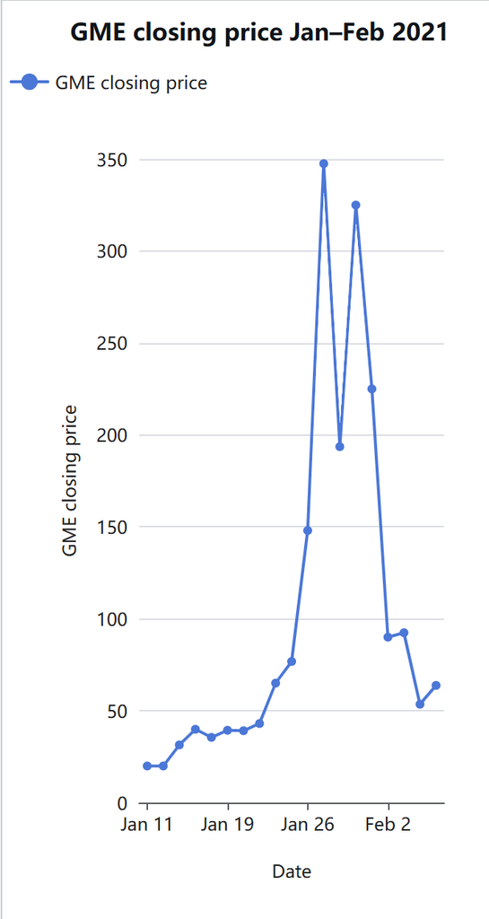

- GME
  - Lots of institutions shorted this stock
- Problem
  - IF the price goes up, then short sellers will buy back the stock to minimize loss
  - That buying creates demand, forcing the price higher
  - Called a short squeeze

## Equilibrium

- In equilibrium, stock prices are stable and there is no general tendency for people to buy versus to sell.
- In equilibrium, two conditions hold:
  - A stock’s market price equals its intrinsic value.
  - Expected returns must equal required returns.

$$\hat{r_s} = \frac{D_1}{P_0} + g \quad = \quad r_s = r_{RF} + \left( r_M - r_{RF} \right) b$$

## Nonconstant growth

- It is not reasonable to assume that a company will always grow at a constant rate
- Especially young companies!
  - Easy to grow when small, harder when big
  - Think humans
- But eventually growth rate will slow, to something we can reasonably assume is constant!

## Supernormal Growth

- Period of time where cashflows grow a high rate
- We assume that this will happen for n periods.
- At time n, then the firm will become a constant growth firm
- How to find price?
  - Find Dividends
  - Find price @ time n
  - PV of that price and all the periods of nonconstant growth
  - Sum PVs

## Remember how we find PV

- A dividend at time 2 is divided by 1 plus the discount rate squared, at time 3 cubed

$$PV = \frac{FV_N}{\left( 1 + r \right)^N}$$

- BUT we will also have the price once the firm switches to constant growth!
  - That must be discounted as well.

## Example

- What is the PV of these cash flows if $r$ = 10%?
  - Year 1: $5
  - Year 2: $10
  - Year 3: $20

$$PV = \frac{CF_1}{1 + r} + \frac{CF_2}{\left( 1 + r \right)^2} + \frac{CF_3}{\left( 1 + r \right)^3}$$

$$PV = \frac{\$5}{1.10} + \frac{\$10}{1.10^2} + \frac{\$20}{1.10^3} = \$4.55 + \$8.26 + \$15.03 = \$27.84$$

- Price = PV of all future cash flows

## Example

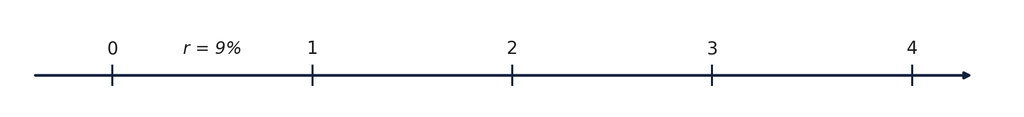

Justin’s cupcakes is planning an expansion to Mississippi State. It is expected to increase growth for the next 3 years before slowing to a constant growth rate of 4% What is the value of the stock if the current dividend is $2, $r_s$=9%, and the growth rates are as follows

g=30% for 1 yr., 20% for 1 yr., and 10% for 1 yr before achieving long-run growth of 4%

## Non Constant Growth

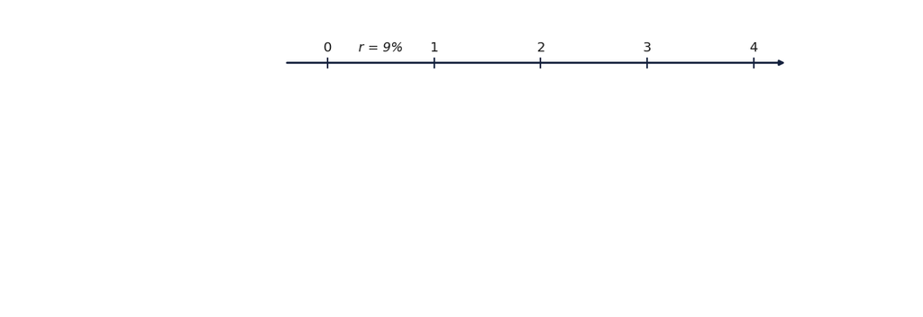

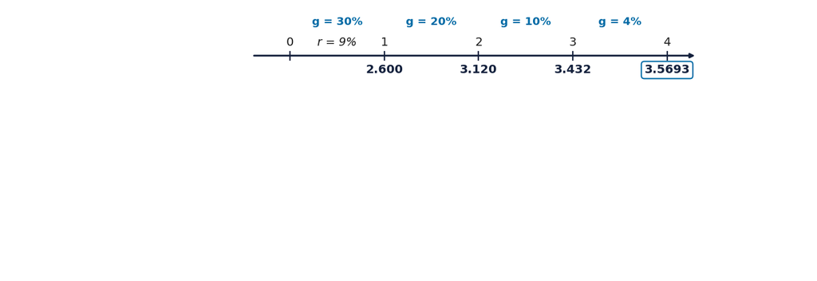

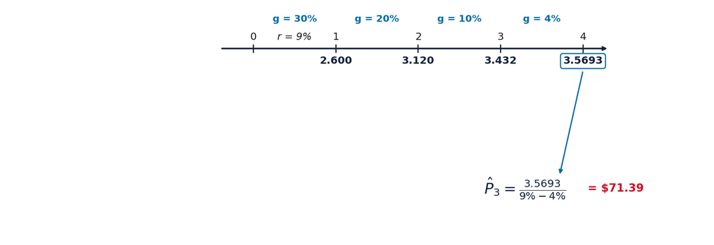

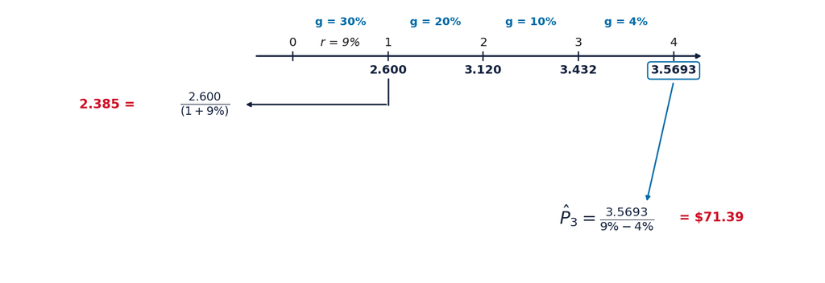

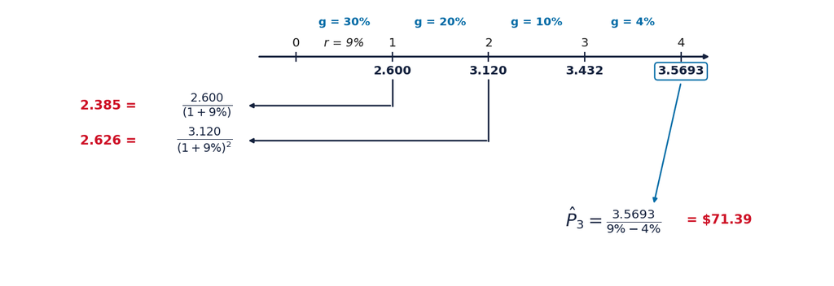

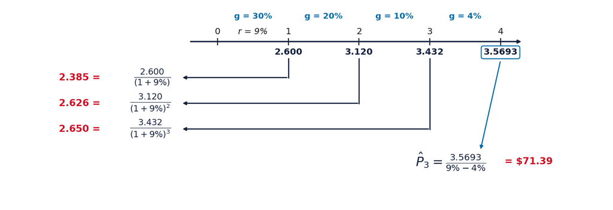

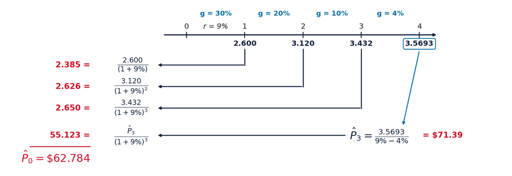

g=30% for 1 yr., 20% for 1 yr., and 10% for 1 yr before achieving long-run growth of 4% D0=$2.00

- Step 1, Find dividends and discount the individual dividends during the super or abnormal growth period at the required rate of return, rs
- Step 2, use the Gordon Growth Model to find the estimated intrinsic value when growth becomes constant at the end of year 3
- Step 3, find the present value of $\hat{P_3}$ by discounting it back to the present at rs
- Step 4, add up all the present values

## Practice: Nonconstant

Taylor’s Cupcakes is expected to have 3 years of no growth and then return to a constant growth rate of 4%. The discount rate is 9%. The current dividend is $2. Draw a timeline and find the price today

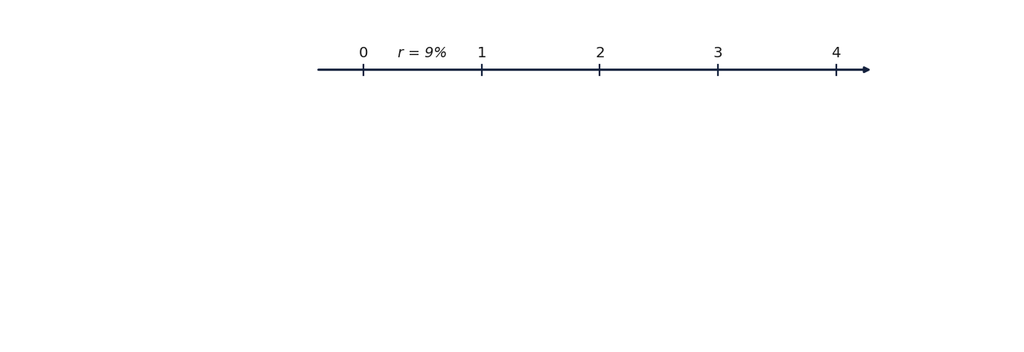

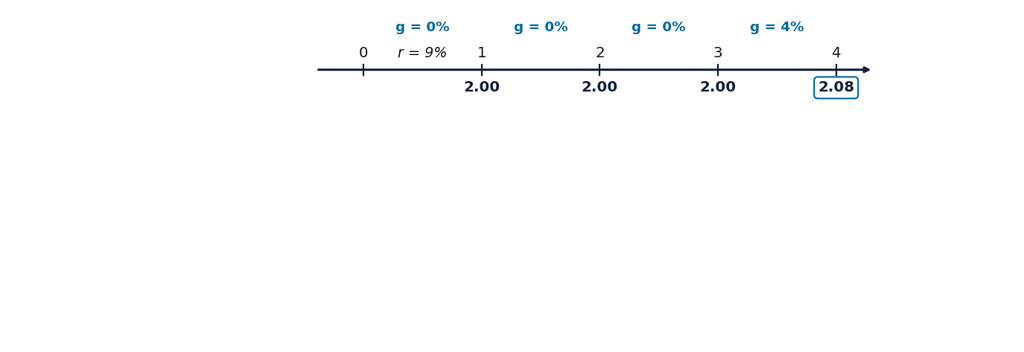

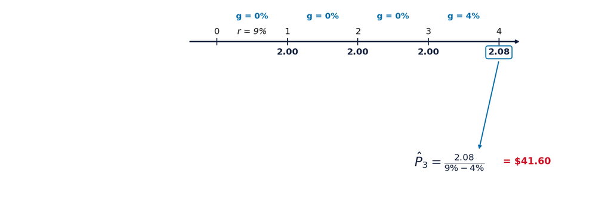

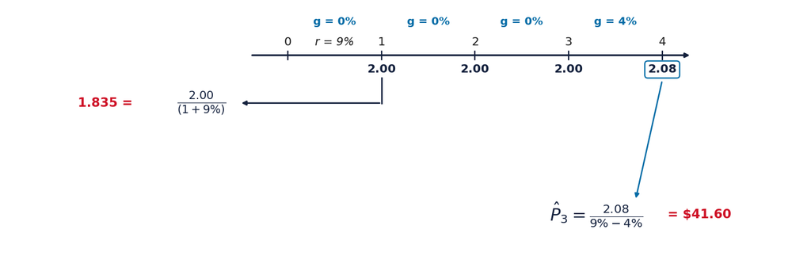

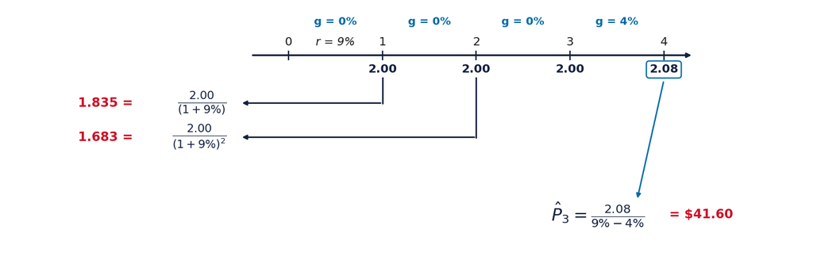

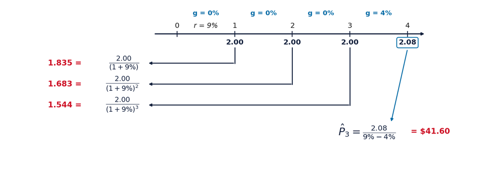

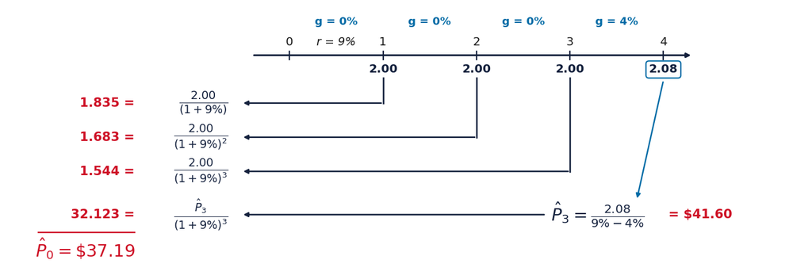

## Value of preferred stock

$$V_p = \frac{\text{Annual Dividend}}{r_s}$$

$$V_p = \text{Value of a preferred share of stock}$$

$$r_s = \text{ Required rate of return on a share of preferred stock}$$

## Multiples

- Analysts often use the following multiples to estimate intrinsic value.
- P/E = Price Earnings Ratio = Amount investors pay for $1 of earnings
- P/CF = Price to Cash Flow
- P/Sales = Price to Sales
- Enterprise-Based Multiples
- EV/EBITDA

## Stock Markets

- What markets are there?
  - NASDAQ, NYSE, etc
- When to trade?
  - Open for trading Monday through Friday from 9:30 a.m. ET to 4:00 p.m. ET.
- How do you access them?
  - Brokers
  - Robinhood?

## How does Robinhood make money?

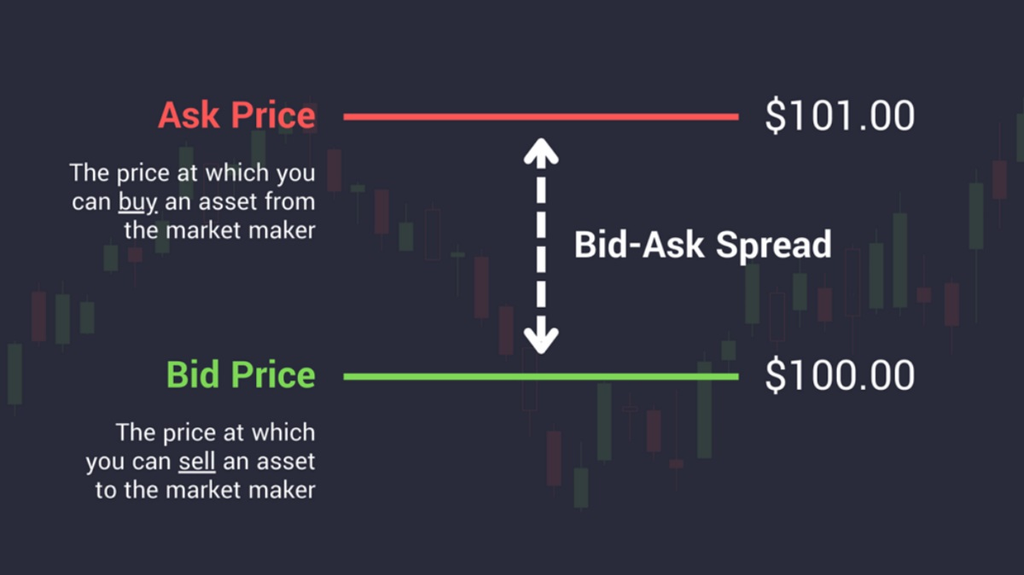

- Payment for Order Flow
  - Simplified: Market Marker
    - Firm that buys and sells
  - Buy low and sell high (think car dealer)
  - Market maker shares part of their profit as a reward for the broker (Robinhood)
- Payments from these dealers to the broker are payments for order flow

https://www.ebc.com/forex/what-is-the-bid-ask-spread-and-why-does-it-matter

## Our Bias

- Confusion about probability -> Underdiversification
- Overconfidence -> Trade too much
- Desire to reduce regret -> Cling to losers
- Confusion about probability again-> Chase performance

## Under diversification

- We all know diversification is good
- Maximum return per unit of risk
- Yet…
- We all pick that stock that we really like (TSLA, GME, AMZN)
- 62% of Enron’s employees 401k was in Enron’s stock!!!!

## Over confidence

- All traders are consider themselves above average
- Then:
- They trade more
- Earn less
- Underdiversify (because they can stock pick)
- Increase market volatility (deviating stock from its fundamentals)

## Retail investors trade too much: nice try!(Brad Barber and Terry Odean)

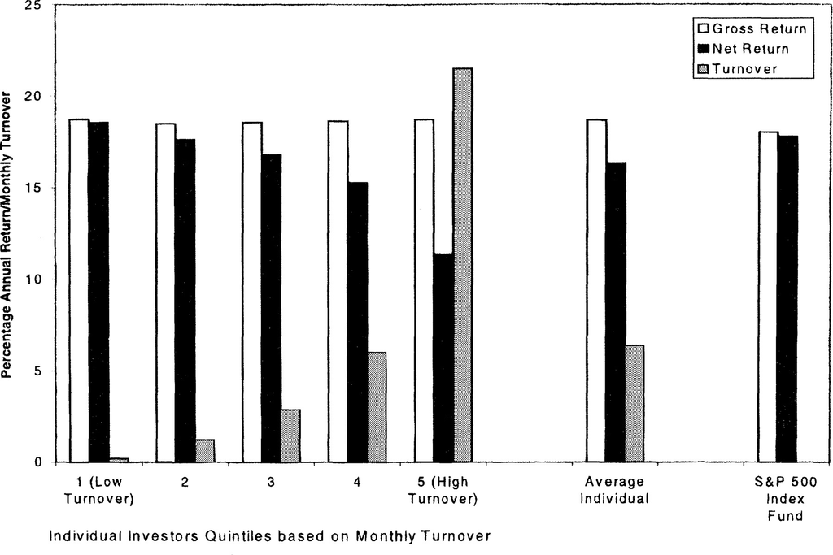

## What drove that old under performance?

- Fees! You used to have to pay brokerage fees
- Do you pay Robinhood anything?
  - NO!
  - PFOF
- Cost of trading too much today?
  - The spread between the bid and ask
- Do they want you to trade a lot?

## Some good UI

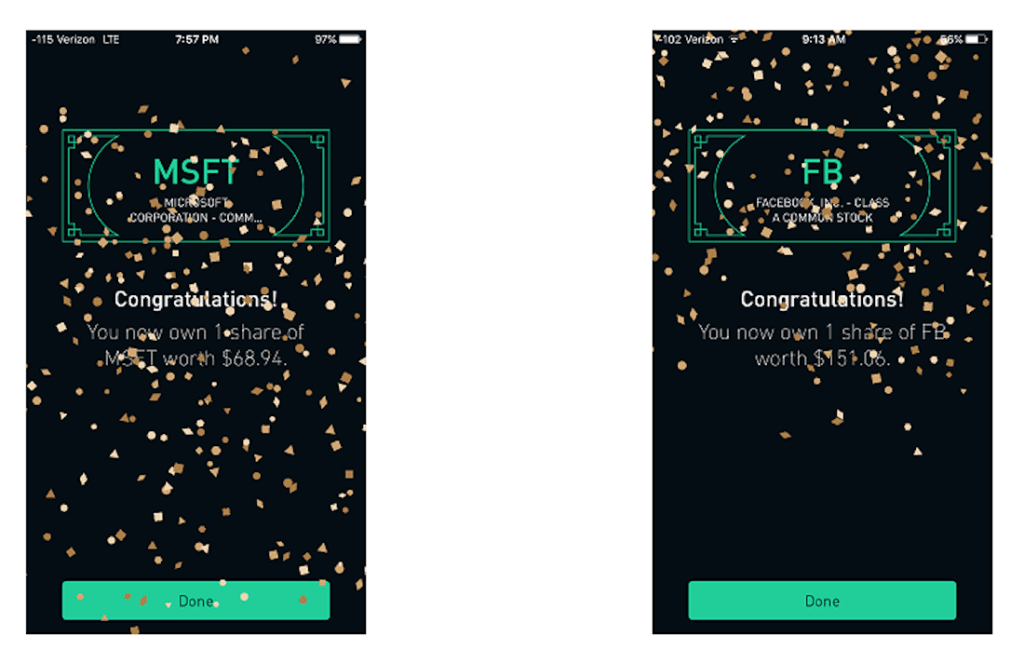

## New research on retail traders

- **Trading bots:** S&P 500 options that expire the same day, 2022 to 2026
  - Retail bots trade at the same clock times every day
  - Market makers see them coming: quoted spreads narrow, but the bots pay wider effective spreads
- **Soccer:** Israeli bank accounts, 2005 to 2014
  - On local game days, investors buy more of what their neighbors bought
  - No effect on sells
- **Daily bonuses:** a social trading platform, 2018 to 2022
  - Traders earn a bonus every day their portfolio closes at a new high
  - Returns jump 1.6 percentage points on bonus days, then fall right back
  - Not trading at all would have given 63% of funds a higher alpha

FMA Annual Meeting, October 2026. Amaya, Garcia-Ares, Pearson and Vasquez; Gelman, Hirshleifer, Levi and Reiter-Gavish; Mohr and Waikel.

## Corporate Valuation Method

- Alternative to the DDM
- Could be that the firm does not pay dividends
- Or we want to value a subsidiary
  - Subset of a larger firm
- We want to use accounting measures to construct value in these cases

## BOO!!!

$$FCF = EBIT \left( 1 - T \right) + Depreciation\ \&\ Amortization - CAPEX - \Delta NOWC$$

## Corporate Valuation

$$FCF = EBIT \left( 1 - T \right) + DEP - CAPEX - \Delta NOWC$$

- MV of the company’s operations is the PV of FCFs
- We do the exact same things as dividend math but now instead of dividends we have FCF, and instead of $r_s$ we have WACC
  - WACC will be discussed in greater detail after our exam
  - For now, it is it the special FCF discount rate you are given

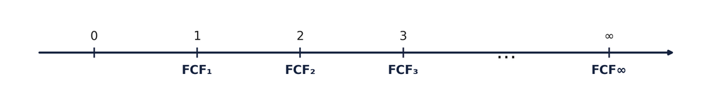

## Assume constant growth

- Then we can express

$$MV\ of\ Operations = \frac{FCF_1}{1 + WACC} + \frac{FCF_2}{\left( 1 + WACC \right)^2} + \frac{FCF_3}{\left( 1 + WACC \right)^3} + ... + \frac{FCF_\infty}{\left( 1 + WACC \right)^\infty}$$

- as

$$MV\ of\ Operations = \frac{FCF_1}{1 + WACC} + \frac{FCF_1 \left( 1 + g \right)}{\left( 1 + WACC \right)^2} + \frac{FCF_1 \left( 1 + g \right)^2}{\left( 1 + WACC \right)^3} + ... + \frac{FCF_1 \left( 1 + g \right)^\infty}{\left( 1 + WACC \right)^\infty}$$

- Some math trickery

$$MV\ of\ Operations = \frac{FCF_1}{WACC - g} = \frac{FCF_0 \left( 1 + g \right)}{WACC - g}$$

## Corporate Valuation Method

- Market value of the company is equal to the MV of operations and the MV of nonoperating assets
- MV=

$$\frac{FCF}{WACC - g_{FCF}} + NOA = \frac{EBIT \left( 1 - T \right) + DEP - CAPEX - \Delta NOWC}{WACC - g_{FCF}} + NOA$$

- Then to get the value of the firm, we divide MV less debt the number of shares outstanding (Equity holders get paid after debt holders)

$$P_0 = \frac{MV - debt}{Shares}$$

## Corporate Valuation

What should this company’s stock price be today under the Corporate Valuation method?

MV of the company is MV Operations+ MV of Nonoperating assets

- Next year EBIT(1-T) is $400M
- Next year depreciation is expected to be $140M
- Next year CAPEX is $225M
- No change in NOWC
- FCF growth of 6%
- Required return on equity is 14%
- WACC is 10%
- $200M of nonoperating assets
- Market value of debt is $3.875B
- 200M share are outstanding

MV=

$$\frac{FCF}{WACC - g_{FCF}} + NOA$$

$$= \frac{EBIT \left( 1 - T \right) + DEP - CAPEX - \Delta NOWC}{WACC - g_{FCF}} + NOA$$

$$= \frac{400M + 140M - 225M - 0}{10\% - 6\%} + 200 = 8.075B$$

$$P = \frac{MV - debt}{Shares} = \frac{8075M - 3875M}{200M} = \$21$$

## Practice Problem

Beowulf Jewelry has a stock price of $30. It recently paid a $1 dividend. The expected dividend growth rate is 30% for the next 3 years and then a constant rate g. If $r_s$ is 9% what is g?

- First, what is the price 3 years from today?

$$P_0 = \frac{D_0 \left( 1 + g \right)}{r_s - g} \rightarrow P_3 = \frac{D_3 \left( 1 + g \right)}{r_s - g}$$

- The price today is then

$$P_0 = 30 = \frac{1 \left( 1 + 30\% \right)}{1 + 9\%} + \frac{1 \left( 1 + 30\% \right)^2}{\left( 1 + 9\% \right)^2} + \frac{1 \left( 1 + 30\% \right)^3}{\left( 1 + 9\% \right)^3} + \frac{\frac{1 \left( 1 + 30\% \right)^3 \left( 1 + g \right)}{9\% - g}}{\left( 1 + 9\% \right)^3}$$

$$\frac{1 \left( 1 + 30\% \right)^3 \left( 1 + g \right)}{9\% - g} = \left( 30 - \frac{1 \left( 1 + 30\% \right)}{1 + 9\%} - \frac{1 \left( 1 + 30\% \right)^2}{\left( 1 + 9\% \right)^2} - \frac{1 \left( 1 + 30\% \right)^3}{\left( 1 + 9\% \right)^3} \right) \ast \left( 1 + 9\% \right)^3$$

$$g = 2.25\%$$

## Upcoming Dates

Upcoming class dates and deadlines

| Date | Topic | Due / Notes |
| --- | --- | --- |
| Thu Oct 22 | Chapter 10: Cost of Capital | - |
| Sun Oct 25 | MindTap Ch 9 | HW DUE |
| Tue Oct 27 | Chapter 10: Cost of Capital | - |
| Thu Oct 29 | Chapter 11: Capital Budgeting | - |

**Office:** 325 Holman Hall · **Office hours:** T TH 10:50A-12:20P · jjmohr1@olemiss.edu